# Assignment 1

Hunter DeVoe

2023-02-06

# Question 1

An overview of the class is shown in the following table

```r
GradeOverview <- read.csv("GradeWeights.csv", header = TRUE, check.names = FALSE)
kable(GradeOverview)
```

| Group | Count | Individual Weight | Total Weight |
| --- | --- | --- | --- |
| Labs | 16 | 0.625% | 10% |
| Assignments | 4 | 3.75% | 15% |
| Projects | 2 | 5% | 10% |
| Clickers | TBD | - | - |
| Chapter Quizzes | TBD | - | 5% |
| In-Class Quizzes | TBD | - | 10% |
| Midterm Exams | 2 | 10% | 20% |
| Final Exam | 1 | 30% | 30% |

Overall grade weightings: A = 100% - 90% | B = 89% - 80% | C = 79% - 60% | D = 59% - 50%| F = 49% - 0%  
No curves are given in this class, likely because the range of a C grade is so large.

# Question 2

## (a)

- Make the coplot as the biologist required

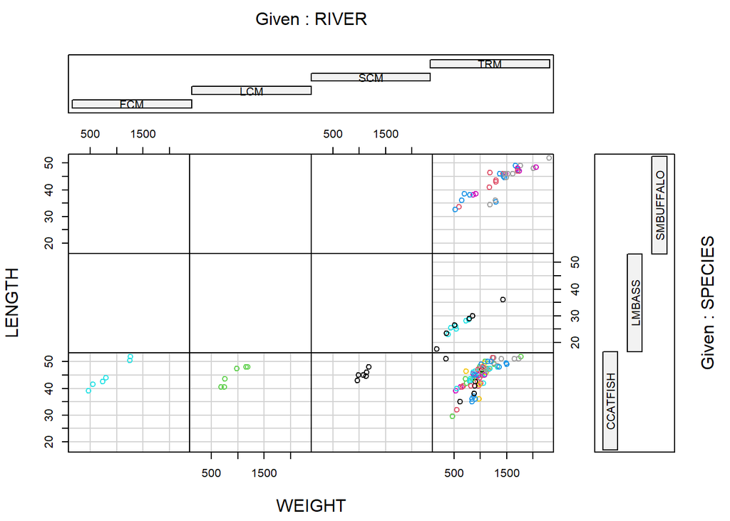

```r
ddt <- read.csv("DDT-1.csv", header = TRUE)

coplot(LENGTH ~ WEIGHT|RIVER*SPECIES, col = ddt$MILE, data = ddt)
```

## (b)

- Interpret the lower left three conditional plots.

## (c)

- What does line A do?

Line A converts the MILE variable from the DDT dataset to a numeric vector.

```r
m=with(ddt, as.numeric(factor(MILE)))
m
```

```
##   [1]  3  3  3  3  3  3  2  2  2  2  2  2  1  1  1  1  1  1  4  4  4  4  4  4  5
##  [26]  5  5  5  5  5  5  5  5  5  5  5  6  6  6  6  6  6  6  6  6  6  6  6  7  7
##  [51]  7  7  7  7  7  7  7  7  7  7  8  8  8  8  8  8  9  9  9  9  9  9  9  9  9
##  [76]  9  9  9 10 10 10 10 10 10 11 11 11 11 11 11 11 11 11 11 11 11 12 12 12 12
## [101] 12 12 13 13 13 13 13 13 13 13 13 13 13 13 14 14 14 14 14 14 15 15 15 15 15
## [126] 15 15 15 16 16 16 16 16 16 16 16 16 16 17 17 17 17 17 17
```

## (d)

- What does line B do?

Line B finds each unique value in m and puts it into a vector. It then finds the length of that vector, which would be 17 since we have 17 unique MILE values.

```r
length(unique(m))
```

```
## [1] 17
```

## (f)

- What is the mean value of DDT found in the sample of CCATFISH caught in the FCM river?

```r
subsetSpeciesRiver <- subset(ddt, RIVER == "FCM" & SPECIES == "CCATFISH")
mean(subsetSpeciesRiver$DDT)
```

```
## [1] 45
```

# Question 3

## (a)

Length of maximum span - Quantitative

## (b)

Number of vehicle lanes - Quantitative

## (c)

Toll bridge (yes or no) - Qualitative

## (d)

Average daily traffic - Quantitative

## (e)

Condition of deck (good, fair, poor) - Qualitative

## (f)

Bypass or detour length (miles) - Quantitative

## (g)

Route type (interstate, U.S., state, county, or city) - Qualitative

# Question 4

## (a)

- What are the names of the four random sampling designs (1 simple and 3 more complex).

The four random sampling designs are:

1. Simple random sampling
2. Stratified random sampling
3. Cluster sampling
4. Systematic sampling

## (b)

- Give a brief description of each
1. Simple random sampling - A simple random sample ensures that every subset of fixed size in the population has the same chance of being included in the sample.
2. Stratified random sampling - Stratified random sampling is used when the experimental units associated with a population can be separated into different groups, where similar experimental units are put into one group. These groups are called strata. Random samples of the experimental units are obtained for each strata, and they are combined to form a complete sample.
3. Cluster sampling - Cluster sampling involves sampling natural groupings of experimental units first. These groupings are called clusters. The data is then collected from all experimental units in a cluster.
4. Systematic sampling - Systematic sampling is where every kth experimental unit is systematically selected from a list of all experimental units.

# Question 5

```r
# Read in the MTBE dataset
MTBE <- read.csv("MTBE.csv", header = TRUE)

# Create random sample
ind <- sample(1:nrow(MTBE), 5, replace = FALSE)

# List of wells that were randomly sampled
MTBE[ind,]
```

```
##       pH SpConduct DissOxy RoadsPct IndPct UrbanPct DevPct WellClass Aquifier
## 17  8.14     209.3    0.59     2.93   0.00    49.47  49.47   Private  Bedrock
## 222 7.75     863.7    0.50     3.17  14.92    41.62  47.58    Public  Bedrock
## 41  7.89    1807.0    0.44     2.17   2.26    38.95  51.00   Private  Bedrock
## 141 8.04     306.1    0.28     3.10   0.00    48.42  51.40    Public  Bedrock
## 135 7.22     286.5    0.60     3.28   0.00    40.78  40.78    Public  Bedrock
##        Depth  SafeYld Distance MTBE.Detect MTBE.Level HouseDen PopDen
## 17   92.9640       NA  2652.00 Below Limit        0.2   159.78   0.00
## 222  45.7200       NA  1358.67 Below Limit        0.2   216.79  64.02
## 41  110.0328       NA  1632.66 Below Limit        0.2    22.61   8.41
## 141 109.7280 113.5503  1729.81 Below Limit        0.2   129.42  56.62
## 135  45.7200 113.5503   367.52 Below Limit        0.2   117.22   0.00
```

## (a)

- Answer the additional problems below

### (i)

- Remove all the rows in MTBE that contain one or more NA’s

```r
MTBE <- na.omit(MTBE)
```

### (ii)

- Now calculate the standard deviation of the depth of wells which have “Bedrock” as the Aquifer.

```r
subsetBedrock <- subset(MTBE, Aquifier == "Bedrock")
sd(subsetBedrock$Depth)
```

```
## [1] 56.45357
```

# Question 6

```r
# Read in the MTBE dataset
Earthquake <- read.csv("EARTHQUAKE.csv", header = TRUE)

# Create random sample
ind <- sample(1:nrow(Earthquake), 30, replace = FALSE)

# List of aftershocks that were randomly sampled
Earthquake[ind,]
```

```
##      YEAR MONTH DAY HOUR MINUTE MAGNITUDE
## 2714 1994     2   4    4     37       1.8
## 92   1994     1  17   16     19       3.6
## 267  1994     1  18   12     38       2.6
## 2576 1994     2   3    0     40       1.4
## 1580 1994     1  24   22     51       1.7
## 1083 1994     1  22    5     37       2.2
## 1513 1994     1  24   12     45       1.9
## 52   1994     1  17   14     22       2.3
## 1405 1994     1  23   22      4       1.8
## 2915 1994     2   6    0     25       2.2
## 2108 1994     1  28   10     21       1.3
## 956  1994     1  21   15     34       2.1
## 20   1994     1  17   13      1       3.8
## 1330 1994     1  23   11     24       1.4
```

[output cut: 16 more lines]

## (a)

- Answer the additional problems below

### (i)

- Make the following plot: plot(ts(eq$MAG)) and record it here:

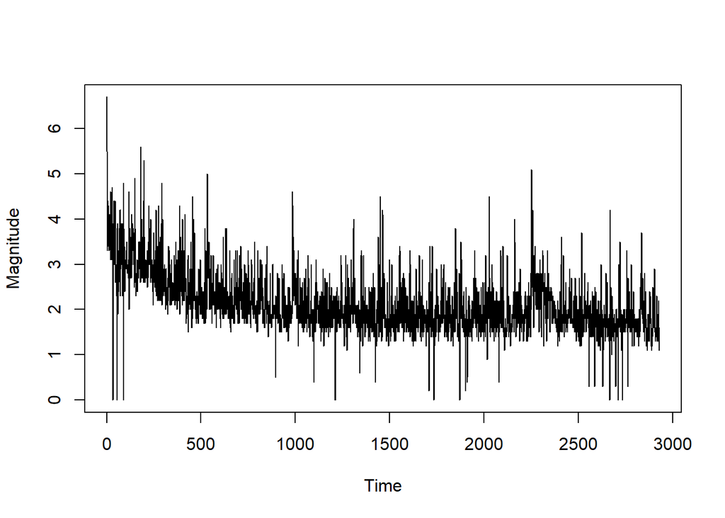

```r
plot(ts(Earthquake$MAGNITUDE), ylab = "Magnitude")
```

### (ii)

- Using the entire Earthquake data frame find the median of the MAGNITUDE variable

```r
median(Earthquake$MAGNITUDE)
```

```
## [1] 2
```